# Activity Monitoring data analysis

Deepika Kulkarni

August 5, 2015

**Part 1:** The data for this project is from personal activity monitoring device. This device collects the data at 5 minute interval through out the day. The data consists of two months data from an anonymous individual collected during the months of October and November, 2012 and include the number of steps taken in 5 minute intervals each day.

*Let us first load the data and process it to get the desired format.*

```r
act<-read.csv("/Users/deepikakulkarni/Documents/RCourse/Reproducible Research Course/activity.csv",header=TRUE)
```

*Creating a new date variable with date format*

```r
act$date_new<-as.Date(act$date)
```

*Creating a variable for days*

```r
act$wday<-weekdays(act$date_new)
```

*Extracting day and month from the date variable*

```r
act$day<-format(act$date_new, format="%d")
act$mon<-format(act$date_new, format="%m")
```

*Creating a new variable by combining day and month so as to split the data*

```r
act$daymon<-paste(act$day, act$mon)
```

*Creating a subset excluding missing values*

```r
act_noNA<-act[complete.cases(act[,1]),]
```

*Calculating the average, sum and median per day ignoring the missing values*

```r
avg_perday<-sapply(split(act_noNA[,1],act_noNA$daymon),mean)
Tot_perday<-sapply(split(act_noNA[,1],act_noNA$daymon),sum)
med_perday<-sapply(split(act_noNA[,1],act_noNA$daymon),median)
```

*Histogram of the total steps per day*

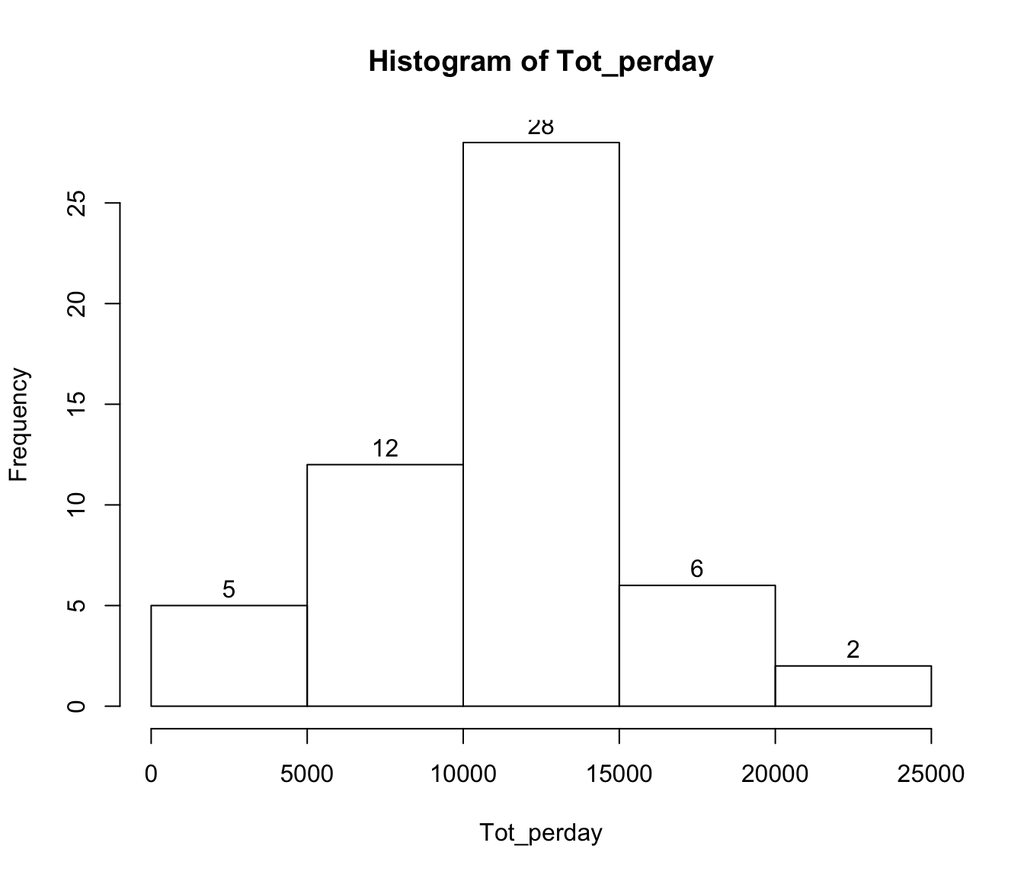

```r
hist(Tot_perday, labels=TRUE)
```

**Part 2:** *Time series plot of average steps taken across all days. Here we have ignored the missing values.*

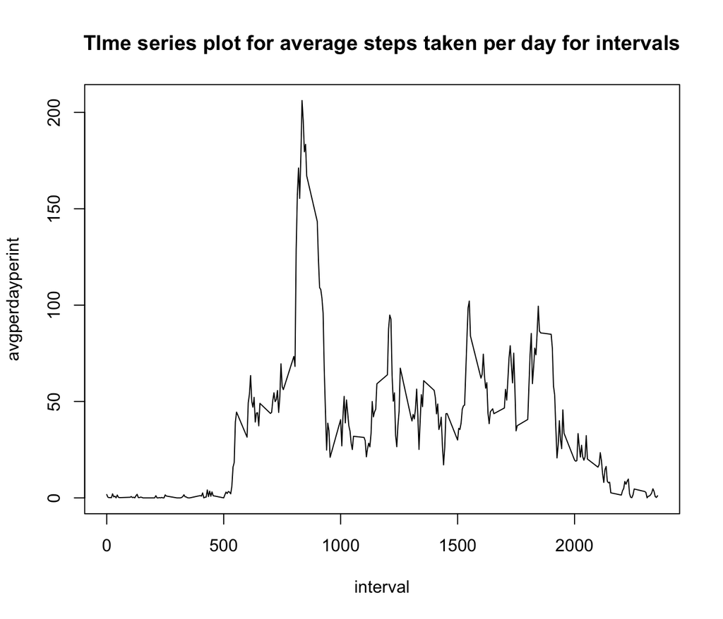

```r
avgperdayperint<-sapply(split(act_noNA[,1],act_noNA$interval),mean)
interval<-unique(act_noNA$interval)
plot(interval,avgperdayperint, type="l", main="TIme series plot for average steps taken per day for intervals")
```

```r
which(avgperdayperint==max(avgperdayperint))
```

```
## 835
## 104
```

The maximum average number of steps are observed at time interval is **08:35**

**Part 3:**

The total number of missing values in the dataset: **2,304**

```r
sum(is.na(act[,1]))
```

```
## [1] 2304
```

**Imputing missing values:**

The missing values of the steps taken for a particular interval are replced by the average steps taken for that interval, taking average over all days for a particular interval.

```r
newdf<-sapply(split(act,act$interval),function(x) replace(x[,1],is.na(x[,1]),mean(x[,1],na.rm=TRUE)))
newdf_vec<-as.vector(newdf)
newact<-act[order(act[,3]),]
newact$new.col<-newdf_vec
newact$steps<-NULL
colnames(newact)[which(colnames(newact) == 'new.col')] <- 'steps'
```

*Calculating average and total number of steps with this new data*

```r
avg_perdaynoMiss<-sapply(split(newact[,8],newact$daymon),mean)
Tot_perdaynoMiss<-sapply(split(newact[,8],newact$daymon),sum)
```

*Histogram using the new data with no missing values*

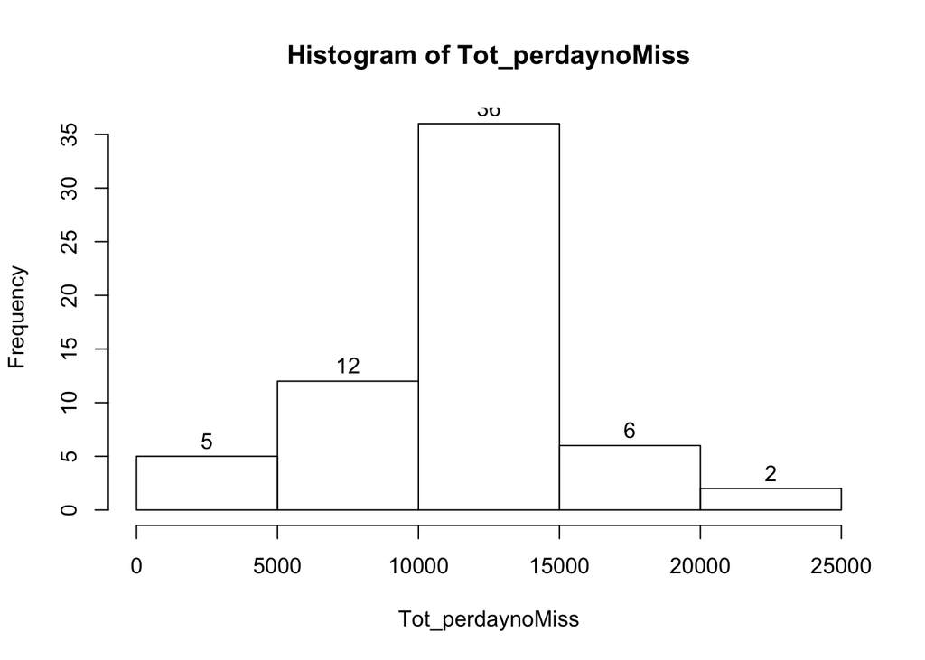

```r
hist(Tot_perdaynoMiss, labels=TRUE)
```

**Part 4:**

*To check whether there is difference in the activity patterns for weekdays and weekend*

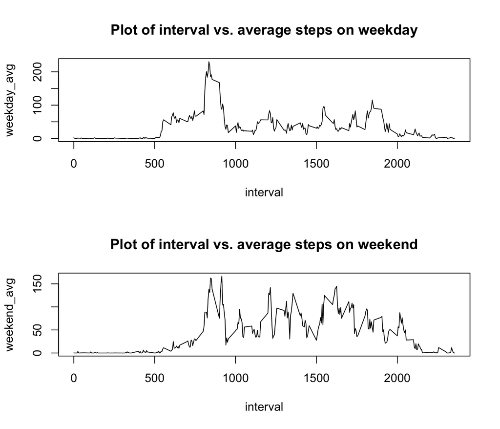

```r
newact$weekdayflag<- ifelse (weekdays(newact$date_new)=="Saturday" | weekdays(newact$date_new)=="Sunday","weekend","weekday")
weekday_data<-subset(newact,newact$weekdayflag=="weekday")
weekend_data<-subset(newact,newact$weekdayflag=="weekend")
weekday_avg<-sapply(split(weekday_data[,8],weekday_data$interval),mean)
weekend_avg<-sapply(split(weekend_data[,8],weekend_data$interval),mean)
par(mfrow=c(2,1))
plot(interval,weekday_avg,type="l",main="Plot of interval vs. average steps on weekday")
plot(interval,weekend_avg,type="l",main="Plot of interval vs. average steps on weekend")
```

The time series plots above suggest that, an individual is tend to be more active on weekends than weekdays.